# IODS course project

Klas Linderborg

# Chapter 1

This is about to be an interesting learning experience.

My github repository: https://github.com/linderbo/IODS-project/

# Excercise 2 - linear regression model

## Introduction and data

We are analyzing data from a survey of students enrolling in the course (Introduction to Social Statistics, fall 2014 - in Finnish).

The data is imported from this repository with the code below, and the structure and dimensions of data is checked.

```r
learning2014 <- read.table("data/learning2014.txt")
str(learning2014)
```

```
## 'data.frame':    166 obs. of  7 variables:
##  $ gender  : Factor w/ 2 levels "F","M": 1 2 1 2 2 1 2 1 2 1 ...
##  $ age     : int  53 55 49 53 49 38 50 37 37 42 ...
##  $ attitude: num  3.7 3.1 2.5 3.5 3.7 3.8 3.5 2.9 3.8 2.1 ...
##  $ deep    : num  3.58 2.92 3.5 3.5 3.67 ...
##  $ stra    : num  3.38 2.75 3.62 3.12 3.62 ...
##  $ surf    : num  2.58 3.17 2.25 2.25 2.83 ...
##  $ points  : int  25 12 24 10 22 21 21 31 24 26 ...
```

We imported the data from a .txt file and can see that there are 166 observations (students) and 7 variables. Variables include *gender*, *age*, Global *attitude* towards statistics, and combined variables that are the mean of questions in the dimensions of *deep*, *strategic* and *surface*, and finally *points* on the exam.

Let´s explore the data!

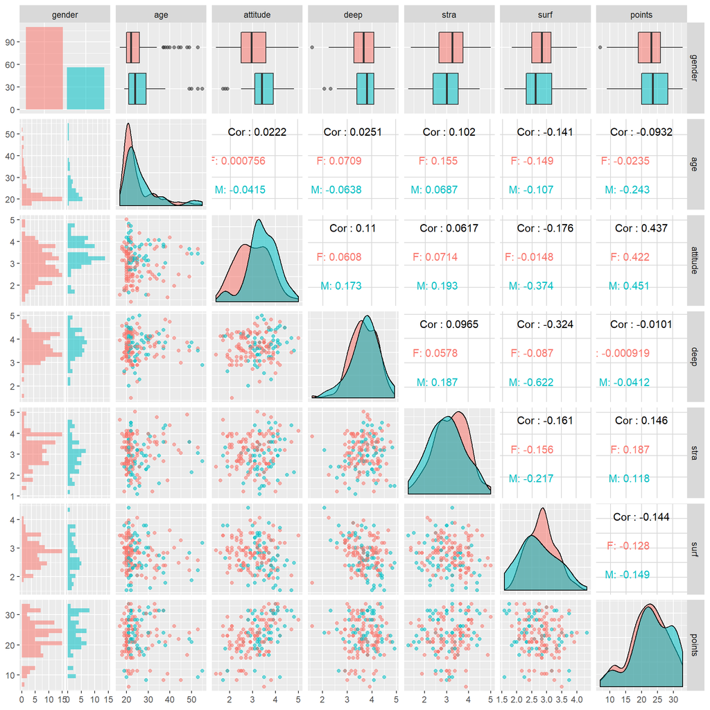

```r
# i increased the figure size for readability in the r code chunk header. See source code for details
# access the GGally and ggplot2 libraries
library(ggplot2)
library(GGally)

# create a plot matrix with ggpairs()
p <- ggpairs(learning2014, mapping = aes(col = gender, alpha = 0.3), lower = list(combo = wrap("facethist", bins = 20)))
# draw the plot
p
```

This shows a scatter matrix of the observations grouped by gender. There were more females in the course. Correlations between variables can be seen as black after “Cor:” The highest correlation can be found between *attitude* and *points*.

## Regression analysis

We´ll create linear regression models for *attitude*, *deep* and *stra* as explanatory variables with *points* as target variable, and print out a summary

```r
#we assign the linear model to themodel
themodel <- lm(formula = points ~ attitude + stra + deep, data = learning2014)
summary(themodel)
```

```
##
## Call:
## lm(formula = points ~ attitude + stra + deep, data = learning2014)
##
## Residuals:
##      Min       1Q   Median       3Q      Max
## -17.5239  -3.4276   0.5474   3.8220  11.5112
##
## Coefficients:
##             Estimate Std. Error t value Pr(>|t|)
## (Intercept)  11.3915     3.4077   3.343  0.00103 **
## attitude      3.5254     0.5683   6.203 4.44e-09 ***
## stra          0.9621     0.5367   1.793  0.07489 .
## deep         -0.7492     0.7507  -0.998  0.31974
## ---
## Signif. codes:  0 '***' 0.001 '**' 0.01 '*' 0.05 '.' 0.1 ' ' 1
##
## Residual standard error: 5.289 on 162 degrees of freedom
## Multiple R-squared:  0.2097, Adjusted R-squared:  0.195
## F-statistic: 14.33 on 3 and 162 DF,  p-value: 2.521e-08
```

With regards to the predictors *deep* and *stra* p is above the commonly used limit of 0.05 and thus they are not statistically significant predictors of exam points.

We´ll remove *deep* and *stra* from the model and run it again.

```r
modelatt <- lm(formula = points ~ attitude, data = learning2014)
summary(modelatt)
```

```
##
## Call:
## lm(formula = points ~ attitude, data = learning2014)
##
## Residuals:
##      Min       1Q   Median       3Q      Max
## -16.9763  -3.2119   0.4339   4.1534  10.6645
##
## Coefficients:
##             Estimate Std. Error t value Pr(>|t|)
## (Intercept)  11.6372     1.8303   6.358 1.95e-09 ***
## attitude      3.5255     0.5674   6.214 4.12e-09 ***
## ---
## Signif. codes:  0 '***' 0.001 '**' 0.01 '*' 0.05 '.' 0.1 ' ' 1
##
## Residual standard error: 5.32 on 164 degrees of freedom
## Multiple R-squared:  0.1906, Adjusted R-squared:  0.1856
## F-statistic: 38.61 on 1 and 164 DF,  p-value: 4.119e-09
```

According to the model, for each 1 point increase in attitude, the exam points are incresed by 3.53 points. The relationship is statistically significant: p = 4.119e-09.

R squared is a measure of how much of the total variation is explained by the model. Multiple R squared is 0.1906, indicating that in this model attitude accounts for 19% of variance in exam points.